# Sea level pressure

## ATMOSPHERIC-PRESSURE-OBSERVATION sea level pressure

The air pressure relative to Mean Sea Level (MSL).

MIN: 08600 MAX: 10900 UNITS: Hectopascals

SCALING FACTOR: 10

DOM: A general domain comprised of the numeric characters (0-9).

99999 = Missing

Atribút sea level pressure reprezentuje atmosférický tlak meraný v hektopascaloch.

```r
all_data <- read.csv(file= "../data/all.csv")
```

```r
summary(all_data$SLP)
```

```
##    Min. 1st Qu.  Median    Mean 3rd Qu.    Max.    NA's
##   970.6  1012.0  1016.9  1017.3  1022.2  1049.4  224734
```

```r
all_data['SLP'] %>% profiling_num()
```

| variable | mean | std_dev | variation_coef | p_01 | p_05 | p_25 | p_50 | p_75 | p_95 | p_99 | skewness | kurtosis | iqr | range_98 | range_80 |
| --- | --- | --- | --- | --- | --- | --- | --- | --- | --- | --- | --- | --- | --- | --- | --- |
| SLP | 1017.295 | 8.221255 | 0.008081483 | 997.5 | 1004.5 | 1012 | 1016.9 | 1022.2 | 1031.8 | 1037.8 | 0.1264733 | 3.539679 | 10.2 | [997.5, 1037.8] | [1007.5, 1028.2] |

```r
getmode(na.omit(all_data$SLP)) # modus
```

```
## [1] 1017
```

### Centralna poloha dat

Hodnota výberového mediánu je 1016.9 hPa. Hodnota výberového priemeru je 1017.3 hPa. Hodnoty sú takmer rovnaké.

Modus - najčastejšia hodnota je 1017 hPa.

```r
var(all_data$SLP, na.rm = T) # rozptyl
```

```
## [1] 67.58904
```

```r
max(all_data$SLP, na.rm = T) - min(all_data$SLP, na.rm = T) # variacne rozpatie
```

```
## [1] 78.8
```

```r
# Interquartile range and outliers
Q1 <- quantile(all_data$SLP, 0.25, na.rm = T) # 25% hodnot je mensich a 75% vacsich
Q3 <- quantile(all_data$SLP, 0.75, na.rm = T) # 75% hodnot je mensich a 25% vacsich
IQR <- IQR(all_data$SLP, na.rm = T) # interquartile range
IQR_dev <- IQR/2

# odlahle hodnoty
length(which(all_data$SLP < (Q1 - 1.5*IQR)))
```

```
## [1] 1526
```

```r
length(which(all_data$SLP > (Q3 + 1.5*IQR)))
```

```
## [1] 2066
```

```r
# extremne hodnoty
length(which(all_data$SLP < (Q1 - 3*IQR)))
```

```
## [1] 45
```

```r
length(which(all_data$SLP > (Q3 + 3*IQR)))
```

```
## [1] 0
```

### Variabilita

Výberový rozptyl je 67.58904.

Výberová smerodajná odchýlka je 8.221255. To znamená, že hodnoty atmosférického tlaku sa pohybujú približne v rozsahu 8.221255 okolo priemeru.

Medzikvartilová odchýlka (IQR/2) je 5.1, teda hodnoty sú rozptýlené približne 5.1 okolo mediánu.

Variačné rozpätie je 78.8. Daná hodnota predstavuje rozdiel medzi maximálnou a minimálnou nameranou hodnotou atmosférického tlaku. Maximálna hodnota atm. tlaku 1049.4 a minimálna 970.6 hPa.

Variačný koeficient 0.008081483, čo je iba 0.8%, teda hodnoty atmosférického tlaku nie sú variabilné.

### Asymetria

Hodnota šikmosti je kladná 0.1264733, ale blízka 0, teda dáta nie sú veľmi zošikmené a ide o symetrické rozdelenie okolo strednej hodnoty.

Hodnota špicatosti je 3.539679, je o niečo väčšia ako 3 teda hodnoty majú špicatejšie rozdelenie. To znamená, že v súbore sa nachádza viac hodnôt bližších k strednej hodnote.

### Boxplot

Hodnota 3.kvartilu je 1022.2 a hodnota 1. kvartilu 1012, teda medzikvartilové rozpätie (IQR) je 10.2. Uprostred krabice je zvýraznený medián hrubou čiernou čiarou (1017). Medián sa nachádza v strede krabice, teda vyzerá, že dáta sú symetrické okolo strednej hodnoty.

Ďalej z boxplotu vidieť maximálnu a minimálnu hodnotu (vonkajšie hradby boxplotu). Maximálna hodnota (1037.5) je vypočítaná ako 3.kvartil + 1.5 * IQR (medzikvartilové rozpätie). Minimálna hodnota (996.7) je vypočítaná ako 1.kvartil - 1.5 * IQR (medzikvartilové rozpätie).

Nakoniec pre odľahlé hodnoty overíme či patria medzi extrémne. Horná hranica extrémych hodnôt je vypočítaná ako 3.kvartil + 3 * IQR. Dolná hranica extrémych hodnôt je vypočítaná ako 1.kvartil - 3 * IQR. V dátach sa nachádza 45 extrémne nízkych hodnôt, ktoré sú nižšie ako hodnota 1.kvartilu - 3 * IQR, teda nižšie ako 981.4 hPa. Extrémne vysoké hodnoty sa v dátach nenachádzajú.

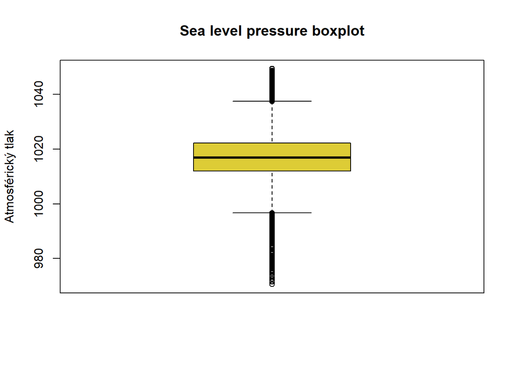

```r
# boxplot
boxplot(all_data$SLP, col = "#ddcc36", ylab = "Atmosférický tlak", main = "Sea level pressure boxplot")
```

### Histogram

Aj z histogramu vidíme, že rozdelenie hodnôt sa podobá na normálne, pričom najpočetnejšie sú hodnoty okolo 1010 - 1020 hPa.

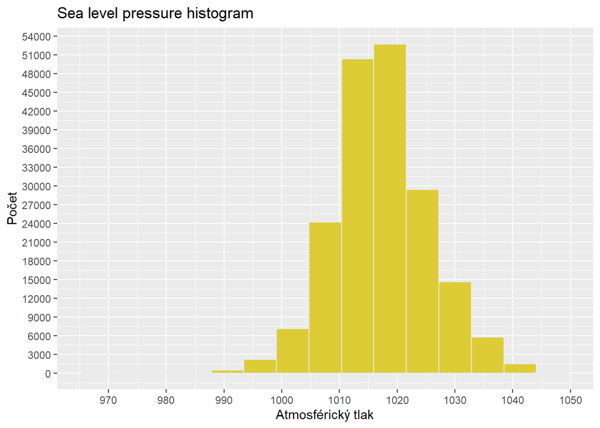

```r
# histogram
ggplot(all_data, aes(x = SLP)) +
  geom_histogram(bins = 15, fill = "#ddcc36", color = "#e9ecef") +
  labs(title = paste("Sea level pressure histogram")) +
  xlab("Atmosférický tlak") +
  ylab("Počet") +
  scale_x_continuous(breaks = seq(950, 1200, by = 10)) +
  scale_y_continuous(breaks = seq(0, 60000, by = 3000))
```

### Graf hustoty

Graf hustoty slúži na porovnanie priebehu hustoty pravdepodobnosti normálneho rozdelenia (zelená čiara) a odhadu hustoty vypočítaného z namernaých hodnôt atmosférického tlaku (červená čiara). Čiary sú približne rovnaké, teda ide o normálne rozdelenie, ktoré je ale trocha špicatejšie. Modrá prerušovaná čiara predstavuje priemernú hodnotu atmosférického tlaku.

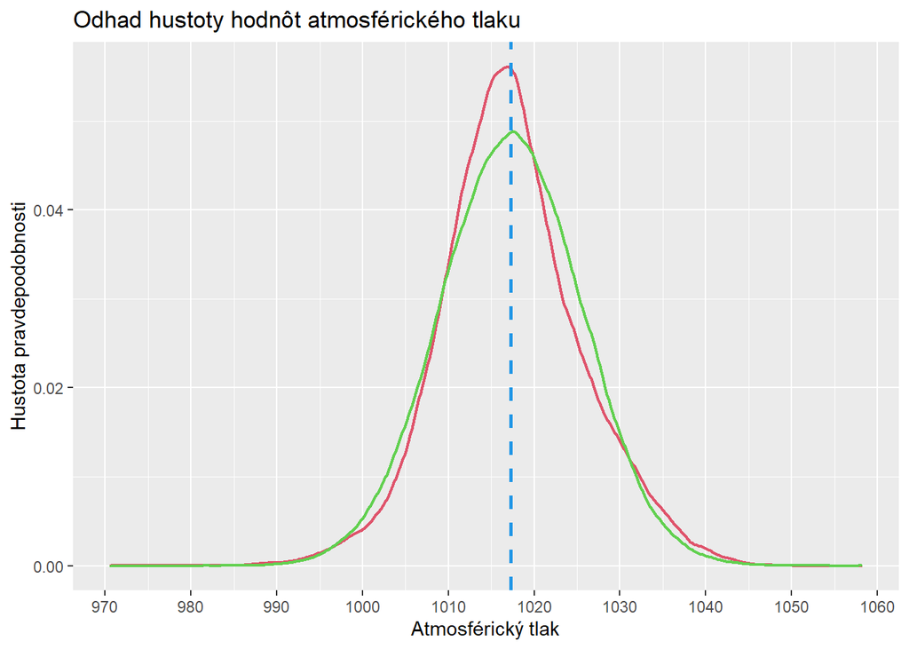

```r
# denisty plot
# data z normalneho rozdelenia
data_norm <- data.frame(dens = c(rnorm(length(na.omit(all_data$SLP)), mean(all_data$SLP, na.rm = T), sd(all_data$SLP, na.rm = T))))

# porovnanie hodnot normalneho rozdelenia a SLP
ggplot(all_data, aes(x = SLP), color = 3) +
  geom_density(color = 2, size = 0.8) +
  geom_density(data_norm, mapping = aes(x = dens), color = 3, size = 0.8) +
  geom_vline(aes(xintercept = mean(SLP, na.rm = T)),
            color = 4, linetype = "dashed", size = 1) +
  scale_x_continuous(breaks = seq(900, 1100, by = 10)) +
  labs(title = paste("Odhad hustoty hodnôt atmosférického tlaku")) +
  xlab("Atmosférický tlak") +
  ylab("Hustota pravdepodobnosti")
```

### Husľový graf

Husľový graf doplnený o hlavné kvartily zobrazuje rozdelenie hustoty, pričom aj podľa tohto grafu vidíme, že ide o normálne rozdelenie. Dáta sú najpočetnejšie v okolí hodnoty 1017, postupne smerom k vyšším a nižším hodnotám sa ich hustota zmenšuje.

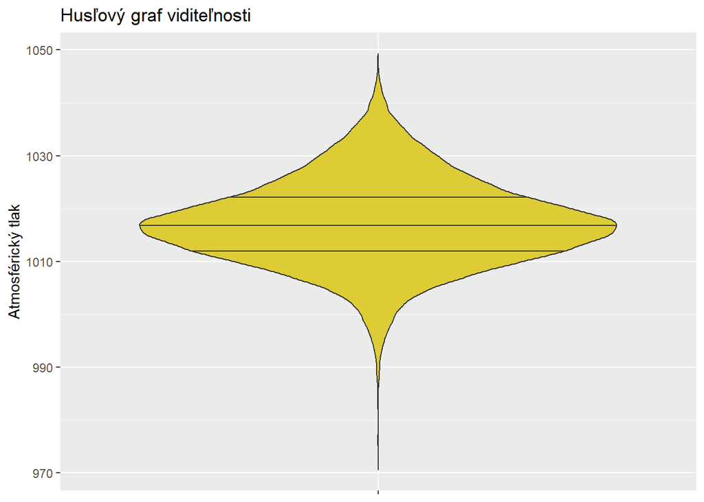

```r
# violin plot
df <- all_data %>%
  dplyr::select('SLP') %>%
  tidyr::gather(key = 'label', value = 'slp')

ggplot(data = df, aes(factor(label), slp, fill = slp)) +
  geom_violin(draw_quantiles = c(0.25, 0.5, 0.75), fill = "#ddcc36") +
  labs(title = paste("Husľový graf viditeľnosti"), y = "Atmosférický tlak", fill = "Sea level pressure") +
  theme(axis.title.x = element_blank()) +
  theme(axis.text.x = element_blank())
```

### Q-Q graf

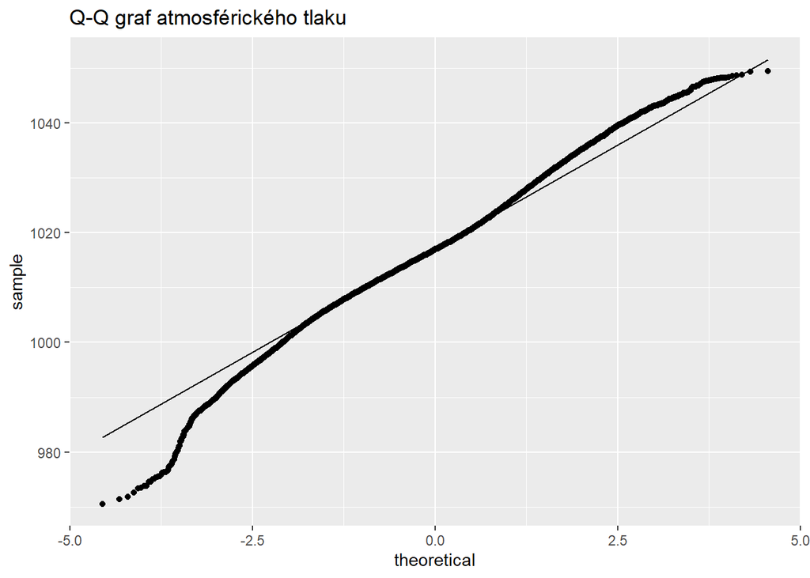

```r
# QQ plot
ggplot(data = all_data, aes(sample = SLP)) +
  stat_qq() +
  stat_qq_line() +
  labs(title = paste("Q-Q graf atmosférického tlaku"))
```

### Graf polosum

Z grafu vidno, že hodnoty sú takmer symetrické okolo mediánu.

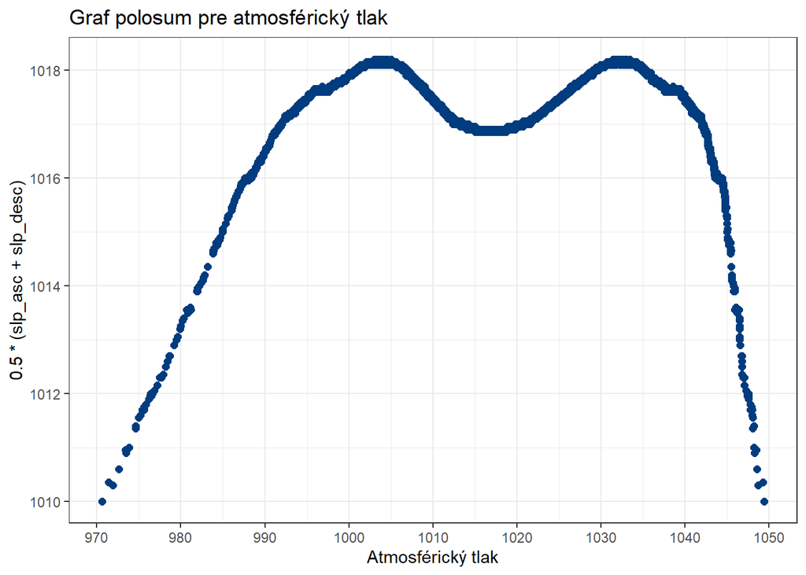

```r
# polosum
slp <- all_data$SLP
slp_asc <- sort(slp, decreasing = FALSE)
slp_desc <- sort(slp, decreasing = TRUE)

ggplot(data.frame(slp_asc), aes(x = slp_asc, y = 0.5*(slp_asc + slp_desc))) +
  geom_point(size = 2, color = "#013c7f") +
  scale_x_continuous(breaks = seq(0, 2000, by = 10)) +
  labs(title = "Graf polosum pre atmosférický tlak", x = "Atmosférický tlak") +
  theme_bw()
```